— .class#id

## Locations of Earthquakes near the Tonga Trench

This is a presentation to show the frequency of earthquakes that occur near the Tonga Trench using various data products. The presentation will utilize multiple products that were demonstrated in the ‘Developing Data Products’ course offered by [Coursera](https://www.coursera.org/).

The data used in this presentation is comprised of the “quake”" dataset,available in RStudio, and from [R bollerqvist](http://ekqvist.goeuropeinfo.com/rbloggerqvist). The Classifications of the earthquakes were obtained from the [Michigan Tech University UPSeis website](http://www.geo.mtu.edu/UPSeis/magnitude.html).

— .class #id

## Data Products

The following data products were used in this presentation.

> - [Slidify](http://slidify.org/) Reproducible HTML5 slide decks
> - [Shiny](http://shiny.rstudio.com/) Create interactive web application
> - [Google Chart Tools](https://developers.google.com/chart/) Interactive charts for brosers
> - [GitHub](https://www.github.com) Web-based Git repository hosting service
> - [Rpubs](http://www.rpubs.com) Web publishing service from R

The GitHub for this entire project is available on:

[https://github.com/CjustC/Developing_Data_Products])(https://github.com/CjustC/Developing_Data_Products)

— .class #id

## Tonga Trench

The Tonga Trench is the deepest point in the South Pacific Ocean also known as the “Horizon Deep”. The Tonga Trench is a convergent plate boundary with a convergence rate estimated in some places to be approximately 24cm/year, the fastest plate velocity recorded on the planet. The Tonga Trench is part of the “Ring of Fire”.

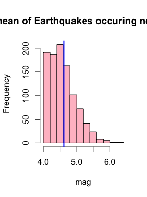

— .class#id

— .class #id

## Shiny Application

The [Shiny application](https://minionapp.shinyapps.io/quake_app/) demonstrates the classification of earthquakes located near the Tonga Trench. The user interaction is to move the slider to any point within the slider range and the application will output the classification of the earthquake.

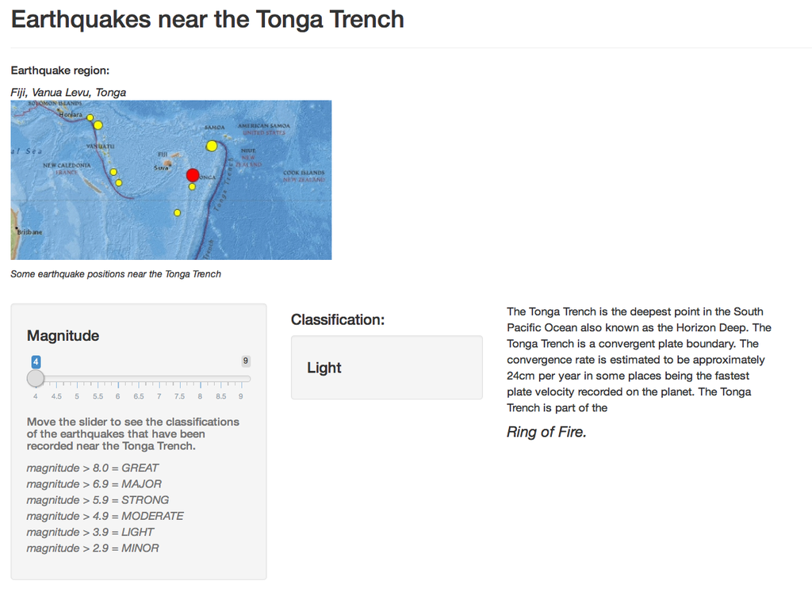